# pitch_clustering

Statcast metrics offer an in depth look at pitching characteristics in Major League Baseball. When considering matchups between specific batters and pitchers, the usual discussions center around past matchup performance and handedness of the pitcher. The lefty/righty angle has limited impact, and there is often not enough data on specific batter/pitcher matchups to make meaningful predictions.

I am aiming to look closer at pitching statistics such as spin rate, spin axis, release arm angle etc. and group pitchers together who have similar characteristics. I've decided to break this down by the five most common pitch types, and by the hand the pitcher throws with(I'm splitting this up by hand because the spin metrics vary wildly between left handed and right handed pitchers).

I will use K-means clustering to cluster the pitchers, and will make a total of 10 models. At the end we will be able to view clustering results for right handed pitchers throwing sliders, left handed pitchers throwing fastballs, and so on.

```python
from pyspark.ml.clustering import KMeans
from pyspark.ml.evaluation import ClusteringEvaluator
from pyspark.ml.feature import VectorAssembler
from pyspark.sql.session import SparkSession
from sklearn.decomposition import PCA
import pandas as pd
import matplotlib.pyplot as plt
from google.cloud import bigquery
```

I'm going to use the Spark machine learning library for clustering. I have statcast data stored in Google Bigquery, so the first step is reading that into a spark dataframe.

```python
spark = SparkSession.builder.appName('pitchers').config('spark.jars.packages', 'com.google.cloud.spark:spark-bigquery-with-dependencies_2.12:0.24.2').getOrCreate()

data = spark.read.format("com.google.cloud.spark.bigquery").option(
    "table", "main.pitch_metrics").load()

data.createOrReplaceTempView("stats")
```

```
:: loading settings :: url = jar:file:/usr/lib/spark/jars/ivy-2.4.0.jar!/org/apache/ivy/core/settings/ivysettings.xml
```

```python
# this is the base sql query string for querying the temp tableb
#I'll format it to insert pitch types and the hand the pitcher throws with

query = """
 SELECT pitcher, AVG(release_speed) AS release_speed ,AVG(release_spin_rate) AS release_spin_rate,
 AVG(spin_axis) AS spin_axis,
 AVG(Mx) AS Mx, AVG(Mz) AS Mz, AVG(theta) AS theta
 FROM stats WHERE game_date BETWEEN '2021-4-01' AND '2021-10-01'
 AND p_throws = {} AND pitch_type = {}
 AND pitcher IS NOT NULL
 AND release_speed IS NOT NULL
 AND release_spin_rate IS NOT NULL
 AND spin_axis IS NOT NULL
 And MX IS NOT NULL
 AND Mz IS NOT NULL
 AND Mx IS NOT NULL
 GROUP BY pitcher
 HAVING COUNT(pitch_type) > 100
  """
```

After some iterative steps, I've rewritten most of the tasks for this project as functions for reusability:

```python
#execute sql query. this creates spark dataframe
def create_df(hand, pitch):
    q = query.format(hand, pitch)
    df = spark.sql(q)
    return df
```

```python
#transform the six relevant columns into a vector for each row
def assemble_vector(df):
    assembler = VectorAssembler(
        inputCols=["release_speed", "release_spin_rate", "spin_axis", "Mx","Mz","theta"],
        outputCol="features",
        handleInvalid="skip")
    output = assembler.transform(df)
    return output
```

```python
#function finds optimal k, then returns the prediction labels
evaluator = ClusteringEvaluator()

def find_k(df):
    #iterate over 5 values for k, determine which has best silhouette score
    sil_scores = {}
    for k in range(3, 8):
        kmeans = KMeans().setK(k).setSeed(1)
        model = kmeans.fit(df)
        predictions = model.transform(df)
        silhouette = evaluator.evaluate(predictions)
        sil_scores[k] = silhouette
    # get key with highest value
    best_k = max(sil_scores, key=sil_scores.get)
    return best_k, sil_scores[best_k]
```

```python
#retrieves the cluster predictions from the model
def get_pred_labels(df,k, pitch_type):
    kmeans = KMeans().setK(k).setSeed(1)
    model = kmeans.fit(df)
    predictions = model.transform(df)
    labels = predictions.select("prediction").rdd.flatMap(lambda x: x).collect()
    #labels = predictions.select("prediction").collect()
    ids = predictions.select("pitcher").rdd.flatMap(lambda x: x).collect()
    rows = [[i, pitch_type, l] for i, l in zip(ids, labels)]
    return rows
```

```python
#Scikit-learn has a simple module for principal component analysis.
#I'll use this for visualizing the clusters in 2 dimensions.
#Converts to pandas for easy integration with sklearn
def make_pca(df):
    df = df.toPandas()
    pca = PCA(n_components=2)
    pca_data = pca.fit_transform(df[['release_speed', 'release_spin_rate', 'spin_axis', 'Mx', 'Mz', 'theta']])
    return pd.DataFrame(pca_data)
```

```python
#takes a pandas dataframe containing clustering results after pca transformation and visualizes with matplotlib
def visualize_clusters(df):
    label0 = df.loc[df['label']==0]
    label1 = df.loc[df['label']==1]
    label2 = df.loc[df['label']==2]
    label3 = df.loc[df['label']==3]
    plt.scatter(label0[0] ,label0[1], color = 'red')
    plt.scatter(label1[0] ,label1[1], color = 'blue')
    plt.scatter(label2[0] ,label2[1], color = 'green')
    plt.scatter(label3[0] ,label3[1], color = 'yellow')
    plt.show()
```

```python
#converts results to pandas dataframes
def make_pandas_results(rows):
    df = pd.DataFrame(rows, columns=['pitcher_id','pitch_type','cluster_label'])
    return df
```

This final function takes a list of pitch types and the handedness of the pitchers and carrys out all of the other functions

```python
#list to hold pandas dataframes with results
cluster_results = []
#list to hold pandas dataframes of pca transformed results for viz
pca_data = []

def make_models(pitch_types, p_throws):
    for pitch in pitch_types:
        #create a spark df with bigquery data
        dataframe = create_df(f'"{p_throws}"', f'"{pitch}"')
        #prepare data for modeling by creating a vector of relevant columns
        df = assemble_vector(dataframe)
        #get optimal k
        k = find_k(df)
        best_k = k[0]
        #get predictions
        rows = get_pred_labels(df, best_k, pitch)
        #make a pandas dataframe of clustering results
        pandas_results = make_pandas_results(rows)
        pandas_results['p_throws'] = p_throws
        cluster_results.append(pandas_results)
        #make principal components df for visualizing clusters
        pca = make_pca(df)
        labels = pandas_results['cluster_label'].copy()
        pca['label'] = labels
        pca_data.append(pca)
```

Next, I'll make 10 k-means models. There will be 5 each for right handed and left handed pitchers.

```python
# FF = four seam fastball, SI = two seam fastball, SL = slider, CH = changeup, CU = curveball
make_models(['FF', 'SI', 'SL', 'CH', 'CU'], 'R')

#does the same for lefthanded pitchers
make_models(['FF', 'SI', 'SL', 'CH', 'CU'], 'L')
```

```
22/07/01 23:30:16 WARN com.github.fommil.netlib.BLAS: Failed to load implementation from: com.github.fommil.netlib.NativeSystemBLAS
22/07/01 23:30:16 WARN com.github.fommil.netlib.BLAS: Failed to load implementation from: com.github.fommil.netlib.NativeRefBLAS
```

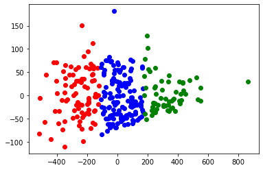

```python
#Visualize clusters for right handed sliders

slider_right = pca_data[2]

visualize_clusters(slider_right)
```

We can see that the clusters for right handed sliders are well segmented. There are a few extreme outliers that may be worth investigating in the future.

For now, I will write the results to a Bigquery table for further analysis.

```python
client = bigquery.Client()

#create a bigquery table for cluster results
job = client.load_table_from_dataframe(
    pd.concat(cluster_results), "myproject.cluster_results")
job.result()
```

```
<google.cloud.bigquery.job.load.LoadJob at 0x7ffa6cf0cbe0>
```